# 07.2_Classification

- The *data leakage* pitfall)
- The *inconsistent preprocessing* pitfall)
- scikit-learn pipelines: Chaining estimators
  - Building and using a pipeline
  - Accessing the steps of a pipeline
  - Pipeline and cross-validation
  - Imbalanced classification and cross-validation
- Classifiers comparison
  - Wilcoxon signed-rank test

The **data mining workflow** involves several steps, including (but not limited to) feature selection, normalization, sampling, classifier training and so on.

The need to combine these steps in a program paves the way to possible **methodological errors**; the most common one are **data leakage** and **inconsistent preprocessing**.

## The *Data Leakage* pitfall ([docs](https://scikit-learn.org/stable/common_pitfalls.html#data-leakage))

Data leakage occurs when information that would not be available at prediction time is used when building the model.

This results in overly optimistic performance estimates, for example from cross-validation, and thus poorer performance when the model is used on actually novel data, for example during production.

A common cause is not keeping the test and train data subsets separate. **Test data should never be used to make choices about the model**. The general rule is to never call `fit` on the test data. Note that the same considerations apply for cross-validation, which can be viewed as an iteration of train-test splits.

## The *Inconsistent Preprocessing* pitfall ([docs](https://scikit-learn.org/stable/common_pitfalls.html#inconsistent-preprocessing))

Both train and test data subsets should receive the same preprocessing transformation: if data transformation operations (normalization, unsupervised dimensionality reduction, feature extraction, ...) are used when training a model, they also must be used on subsequent datasets, whether it’s test data or data in a production system. Otherwise, the feature space will change, and the model will not be able to perform effectively.

It is important that these transformations are only learnt from the training data. For example, if you have a normalization step where you divide by the average value, the average should be the average of the train subset, not the average of all the data. If the test subset is included in the average calculation, information from the test subset is influencing the model.

```python
from sklearn import datasets
breast = datasets.load_breast_cancer()
X, y = breast.data, breast.target
print(breast.DESCR)
```

```
.. _breast_cancer_dataset:

Breast cancer wisconsin (diagnostic) dataset
--------------------------------------------

**Data Set Characteristics:**

:Number of Instances: 569

:Number of Attributes: 30 numeric, predictive attributes and the class

:Attribute Information:
    - radius (mean of distances from center to points on the perimeter)
    - texture (standard deviation of gray-scale values)
    - perimeter
    - area
    - smoothness (local variation in radius lengths)
    - compactness (perimeter^2 / area - 1.0)
    - concavity (severity of concave portions of the contour)
    - concave points (number of concave portions of the contour)
    - symmetry
    - fractal dimension ("coastline approximation" - 1)

    The mean, standard error, and "worst" or largest (mean of the three
    worst/largest values) of these features were computed for each image,
    resulting in 30 features.  For instance, field 0 is Mean Radius, field
    10 is Radius SE, field 20 is Worst Radius.

    - class:
            - WDBC-Malignant
            - WDBC-Benign

:Summary Statistics:

===================================== ====== ======
                                        Min    Max
===================================== ====== ======
radius (mean):                        6.981  28.11
texture (mean):                       9.71   39.28
perimeter (mean):                     43.79  188.5
```

[output cut: 63 more lines]

```
ftp ftp.cs.wisc.edu
cd math-prog/cpo-dataset/machine-learn/WDBC/

.. dropdown:: References

  - W.N. Street, W.H. Wolberg and O.L. Mangasarian. Nuclear feature extraction
    for breast tumor diagnosis. IS&T/SPIE 1993 International Symposium on
    Electronic Imaging: Science and Technology, volume 1905, pages 861-870,
    San Jose, CA, 1993.
  - O.L. Mangasarian, W.N. Street and W.H. Wolberg. Breast cancer diagnosis and
    prognosis via linear programming. Operations Research, 43(4), pages 570-577,
    July-August 1995.
  - W.H. Wolberg, W.N. Street, and O.L. Mangasarian. Machine learning techniques
    to diagnose breast cancer from fine-needle aspirates. Cancer Letters 77 (1994)
    163-171.
```

### Wrong #1: data leakage

```python
from sklearn.preprocessing import StandardScaler
from sklearn.model_selection import train_test_split
from sklearn.linear_model import LogisticRegression
from sklearn.metrics import accuracy_score
```

```python
X_new = StandardScaler().fit_transform(X)
X_train, X_test, y_train, y_test = train_test_split(X_new, y, random_state = 42)
y_pred = LogisticRegression().fit(X_train, y_train).predict(X_test)
accuracy_score(y_pred, y_test)
```

```
0.9790209790209791
```

What's wrong here: parameters for scaling (mean and variance) are estimated on the whole dataset (that is, also on the test set)

### Wrong #2 inconsistent preprocessing

```python
X_train, X_test, y_train, y_test = train_test_split(X, y, random_state = 42)
scaler = StandardScaler()
X_train_new = scaler.fit_transform(X_train)

y_pred = LogisticRegression().fit(X_train_new, y_train).predict(X_test)
accuracy_score(y_pred, y_test)
```

```
0.3776223776223776
```

What's wrong here: the train dataset is scaled, whereas the test dataset is not, so model performance on the test dataset is worse than expected.

### Right

- split your data into train and test **first**
- learn your transformation on training data and apply an *all* data

```python
X_train, X_test, y_train, y_test = train_test_split(X, y, random_state = 42)
scaler = StandardScaler()
X_train_new = scaler.fit_transform(X_train) # fit only on training set
X_test_new = scaler.transform(X_test) # transform also the test

y_pred = LogisticRegression().fit(X_train_new, y_train).predict(X_test_new)
accuracy_score(y_pred, y_test)
```

```
0.9790209790209791
```

We have illustrated data leakage and inconsistent preprocessing with a standardization transformation.

This risk of methodological mistake is however relevant with almost all transformations in scikit-learn, including (but not limited to) feature selection, SimpleImputer, PCA.

### Feature selection: Wrong (data leakage)

```python
from sklearn.feature_selection import SelectKBest
X_selected = SelectKBest(k = 2).fit_transform(X, y)
X_train, X_test, y_train, y_test = train_test_split(X_selected, y, random_state = 42)
clf = LogisticRegression()
clf.fit(X_train, y_train)
y_pred = clf.predict(X_test)
accuracy_score(y_test, y_pred)
```

```
0.965034965034965
```

### Feature selection: Right

```python
from sklearn.feature_selection import SelectKBest
X_train, X_test, y_train, y_test = train_test_split(X, y, random_state = 42)
selector = SelectKBest(k = 2)
X_train_selected = selector.fit_transform(X_train, y_train)
clf = LogisticRegression()
clf.fit(X_train_selected, y_train)
X_test_selected = selector.transform(X_test)
y_pred = clf.predict(X_test_selected)
accuracy_score(y_test, y_pred)
```

```
0.8531468531468531
```

[Recap](https://scikit-learn.org/stable/common_pitfalls.html#how-to-avoid-data-leakage) - below are some tips on avoiding data leakage:

- Always split the data into train and test subsets first, particularly before any preprocessing steps.
- Never include test data when using the `fit` and `fit_transform` methods. Using all the data, e.g., `fit(X)`, can result in overly optimistic scores. Conversely, the `transform` method should be used on both train and test subsets as the same preprocessing should be applied to all the data. This can be achieved by using `fit_transform` on the train subset and `transform` on the test subset.
- The **scikit-learn pipeline** is a great way to prevent data leakage as it ensures that the appropriate method is performed on the correct data subset. The pipeline is ideal for use in cross-validation and hyper-parameter tuning functions.

## `sklearn` Pipelines: Chaining estimators

One or more transformers are usually combined with classifiers, regressors or other estimators to build a composite estimator.

Consider the following example.

**Standardization** ➡️ **Feature Selection** ➡️ **Classification**

```python
from sklearn.feature_selection import SelectKBest
X_train, X_test, y_train, y_test = train_test_split(X, y, random_state = 42)

scaler = StandardScaler()
X_train_scaled = scaler.fit_transform(X_train)

selector = SelectKBest(k = 2)
X_train_selected = selector.fit_transform(X_train_scaled, y_train)
clf = LogisticRegression()
clf.fit(X_train_selected, y_train)

X_test_selected = selector.transform(scaler.transform(X_test))
y_pred = clf.predict(X_test_selected)
accuracy_score(y_test, y_pred)
```

```
0.9300699300699301
```

The code becomes more tricky, and it is easier to make mistakes.

**Pipelines can be used to chain multiple estimators into one**, and serve multiple purpose:

- **Convenience and encapsulation**: you only have to call **fit and predict once on your data** to fit a whole sequence of estimators.
- Joint parameter selection: you can **grid search over parameters of all estimators** in the pipeline at once.
- Safety: pipelines help **avoid data leakage from your test data into the trained model**, by ensuring that the same samples are used to train the transformers and predictors.

All estimators in a pipeline, except the last one, must be transformers (i.e. must have a `transform` method). The last estimator may be any type (transformer, classifier, etc.).

### Building and using a `pipeline`

The Pipeline is built using a list of **(key, value) pairs**, where

- the key is a string containing the name you want to give this step
- the value is an estimator object

```python
from sklearn.pipeline import Pipeline
from sklearn.linear_model import LogisticRegression

estimators = [('scaling', StandardScaler()),
              ('feature-selection', SelectKBest(k = 2)),
              ('clf', LogisticRegression())]
pipe = Pipeline(estimators)
pipe
```

```
Pipeline(steps=[('scaling', StandardScaler()),
                ('feature-selection', SelectKBest(k=2)),
                ('clf', LogisticRegression())])
```

The utility function `make_pipeline` is a shorthand for constructing pipelines; it takes a variable number of estimators and returns a pipeline, filling in the names automatically:

```
from sklearn.pipeline import make_pipeline
pipe = make_pipeline(StandardScaler(), SelectKBest(k=2), LogisticRegression())
```

Calling `fit` on the pipeline is the same as

- sequentially calling `fit` on each estimator
- `transform` the input and pass it on to the next step.

Furthermore, **the pipeline has all the methods that the last estimator in the pipeline has**, i.e. if the last estimator is a classifier, the Pipeline can be used as a classifier.

```python
X_train, X_test, y_train, y_test = train_test_split(X, y, random_state = 42)
X_train.shape, X_test.shape, y_train.shape, y_test.shape
```

```
((426, 30), (143, 30), (426,), (143,))
```

```python
pipe.fit(X_train, y_train)
```

```
Pipeline(steps=[('scaling', StandardScaler()),
                ('feature-selection', SelectKBest(k=2)),
                ('clf', LogisticRegression())])
```

```python
y_pred = pipe.predict(X_test)
```

```python
accuracy_score(y_pred, y_test)
```

```
0.9300699300699301
```

### Accessing the steps of a `pipeline`

We can access the steps of a `pipeline` in three ways:

- throught the `steps` attribute
- by index
- by name

```python
pipe.steps[0]
```

```
('scaling', StandardScaler())
```

```python
pipe[0]
```

```
StandardScaler()
```

```python
pipe['scaling']
```

```
StandardScaler()
```

```python
pipe[0].mean_, pipe[0].var_ # mean_ and var_ are used by StandardScaler
```

```
(array([1.41226643e+01, 1.91988498e+01, 9.18850235e+01, 6.54919484e+02,
        9.55561972e-02, 1.02506714e-01, 8.74703427e-02, 4.77440869e-02,
        1.80024413e-01, 6.26067840e-02, 4.02111737e-01, 1.20767089e+00,
        2.86367911e+00, 4.01327254e+01, 7.03638028e-03, 2.53726854e-02,
        3.22836148e-02, 1.18490845e-02, 2.04911479e-02, 3.78268850e-03,
        1.62118592e+01, 2.55068779e+01, 1.06886784e+02, 8.73720657e+02,
        1.31201831e-01, 2.47729484e-01, 2.67697533e-01, 1.12653077e-01,
        2.87796948e-01, 8.33459390e-02]),
 array([1.24650551e+01, 1.78572684e+01, 5.89319980e+02, 1.26752058e+05,
        1.94723904e-04, 2.64279566e-03, 6.16528272e-03, 1.43009048e-03,
        7.17538136e-04, 5.21108983e-05, 8.19102543e-02, 2.95586480e-01,
        4.38772798e+00, 2.30098198e+03, 9.55345930e-06, 3.32364782e-04,
        8.98694858e-04, 3.94166423e-05, 6.39586445e-05, 7.19290442e-06,
        2.28101104e+01, 3.62392201e+01, 1.09138140e+03, 3.18750745e+05,
        5.38065073e-04, 2.22665623e-02, 3.94972575e-02, 4.14130870e-03,
        3.78280424e-03, 3.08363992e-04]))
```

### Pipeline and cross-validation

Our pipeline (*scaling* --> *feature-selection* --> *clf*) can be evaluated on the breast cancer dataset.

```python
import pandas as pd
pd.Series(y).value_counts()
```

```
1    357
0    212
Name: count, dtype: int64
```

```python
from sklearn.model_selection import StratifiedKFold
skf = StratifiedKFold(10, shuffle = True, random_state = 21)
```

```python
pipe
```

```
Pipeline(steps=[('scaling', StandardScaler()),
                ('feature-selection', SelectKBest(k=2)),
                ('clf', LogisticRegression())])
```

```python
from sklearn.model_selection import cross_validate
from sklearn.metrics import accuracy_score, f1_score, make_scorer

results_fsel = cross_validate(pipe, # In previous notebook we had just a classifier here
                         X,
                         y,
                         scoring = {'fscore': make_scorer(f1_score),
                                    'accuracy': make_scorer(accuracy_score)},
                         return_estimator = True,
                         cv = skf,
                         n_jobs = -1)
results_fsel
```

```
{'fit_time': array([0.00261593, 0.00261307, 0.00253701, 0.00262284, 0.00245595,
        0.0027051 , 0.00298309, 0.00297594, 0.00181413, 0.00473332]),
 'score_time': array([0.00101805, 0.00102186, 0.00316215, 0.00102329, 0.00108719,
        0.00109696, 0.0012219 , 0.00111222, 0.00090671, 0.00325179]),
 'estimator': [Pipeline(steps=[('scaling', StandardScaler()),
                  ('feature-selection', SelectKBest(k=2)),
                  ('clf', LogisticRegression())]),
  Pipeline(steps=[('scaling', StandardScaler()),
                  ('feature-selection', SelectKBest(k=2)),
                  ('clf', LogisticRegression())]),
  Pipeline(steps=[('scaling', StandardScaler()),
                  ('feature-selection', SelectKBest(k=2)),
                  ('clf', LogisticRegression())]),
  Pipeline(steps=[('scaling', StandardScaler()),
                  ('feature-selection', SelectKBest(k=2)),
                  ('clf', LogisticRegression())]),
  Pipeline(steps=[('scaling', StandardScaler()),
                  ('feature-selection', SelectKBest(k=2)),
                  ('clf', LogisticRegression())]),
  Pipeline(steps=[('scaling', StandardScaler()),
                  ('feature-selection', SelectKBest(k=2)),
                  ('clf', LogisticRegression())]),
  Pipeline(steps=[('scaling', StandardScaler()),
                  ('feature-selection', SelectKBest(k=2)),
                  ('clf', LogisticRegression())]),
  Pipeline(steps=[('scaling', StandardScaler()),
                  ('feature-selection', SelectKBest(k=2)),
                  ('clf', LogisticRegression())]),
  Pipeline(steps=[('scaling', StandardScaler()),
                  ('feature-selection', SelectKBest(k=2)),
                  ('clf', LogisticRegression())]),
  Pipeline(steps=[('scaling', StandardScaler()),
                  ('feature-selection', SelectKBest(k=2)),
                  ('clf', LogisticRegression())])],
 'test_fscore': array([0.92753623, 0.92957746, 0.98591549, 0.95890411, 0.92537313,
        0.96      , 0.94594595, 0.94117647, 0.97297297, 0.95774648]),
 'test_accuracy': array([0.9122807 , 0.9122807 , 0.98245614, 0.94736842, 0.9122807 ,
        0.94736842, 0.92982456, 0.92982456, 0.96491228, 0.94642857])}
```

### Imbalanced classification and cross-validation

We know that `scikit-learn` does not natively handle methods for *imbalanced learning*, but `imblearn` does.

We can use the pipelines of imblearn in exactly the same way as those of scikit-learn, so that we can correctly perform rebalancing when working in cross-validation.

```
from imblearn.pipeline import Pipeline
from imblearn.over_sampling import SMOTE

pipe = Pipeline([
        ('sampling', SMOTE()),
        ... ,
        ('classification', LogisticRegression())
    ])

results = cross_val_score(pipe, X, y, ...)
```

## Classifiers comparison

It is often the case that we want to compare different classifiers, or different configurations of parameters. We can approach this problem using statistical analysis.

In this exercise we want to assess whether using feature-selection is beneficial or not.

**1. Choose the metric to look at: f-score is an option (an averaging strategy must be adopted if we have multiple classes)**

**2. Evaluate the metric distributions fairly (same test splits)**

- we already have results for the *features-selection* experiment
- we use the same `skf` object for the *no-features-selection* experiment

```python
estimators = [('scaling', StandardScaler()),
              ('clf', LogisticRegression())]
pipe_noFsel = Pipeline(estimators)
pipe_noFsel
```

```
Pipeline(steps=[('scaling', StandardScaler()), ('clf', LogisticRegression())])
```

```python
results_nofsel = cross_validate(pipe_noFsel,
                         X,
                         y,
                         scoring = {'fscore': make_scorer(f1_score),
                                    'accuracy': make_scorer(accuracy_score)},
                         return_estimator = True,
                         cv = skf,
                         n_jobs = -1)
```

```python
results_fsel['test_fscore']
```

```
array([0.92753623, 0.92957746, 0.98591549, 0.95890411, 0.92537313,
       0.96      , 0.94594595, 0.94117647, 0.97297297, 0.95774648])
```

```python
results_nofsel['test_fscore']
```

```
array([0.97222222, 0.97222222, 0.98630137, 0.98591549, 0.97142857,
       0.97222222, 0.97297297, 1.        , 1.        , 1.        ])
```

```python
results_fsel['test_fscore'].mean()
```

```
np.float64(0.9505148301928331)
```

```python
results_nofsel['test_fscore'].mean()
```

```
np.float64(0.9833285073888971)
```

**3. Look at the results**

```python
metrics = pd.DataFrame({'fsel': results_fsel['test_fscore'],
                        'nofsel': results_nofsel['test_fscore']})
metrics
```

|  | fsel | nofsel |
| --- | --- | --- |
| 0 | 0.927536 | 0.972222 |
| 1 | 0.929577 | 0.972222 |
| 2 | 0.985915 | 0.986301 |
| 3 | 0.958904 | 0.985915 |
| 4 | 0.925373 | 0.971429 |
| 5 | 0.960000 | 0.972222 |
| 6 | 0.945946 | 0.972973 |
| 7 | 0.941176 | 1.000000 |
| 8 | 0.972973 | 1.000000 |
| 9 | 0.957746 | 1.000000 |

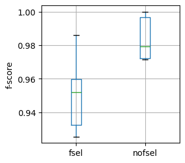

```python
from matplotlib import pyplot as plt
ax = metrics.boxplot(figsize = (3, 3))
ax.set_ylabel('f-score')
plt.show()
```

**4. Apply a statistical test**

#### Statistical tests

- [t-test for paired samples](https://en.wikipedia.org/wiki/Student%27s_t-test#Dependent_t-test_for_paired_samples) ([scipy ref](https://docs.scipy.org/doc/scipy/reference/generated/scipy.stats.ttest_rel.html))
- [Wilcoxon signed-rank test](https://en.wikipedia.org/wiki/Wilcoxon_signed-rank_test) ([scipy ref](https://docs.scipy.org/doc/scipy/reference/generated/scipy.stats.wilcoxon.html))
  - serves the same purpose of student *t*-test for matched samples, but does not assume that the data is normally distributed
  - tests the **null hypothesis** that **two related paired samples come from the same distribution**.

### Wilcoxon signed-rank test

```python
from scipy.stats import wilcoxon
wilcoxon(metrics.fsel, metrics.nofsel)
```

```
WilcoxonResult(statistic=np.float64(0.0), pvalue=np.float64(0.001953125))
```

***p*-value** is the probability of obtaining a value of the W statistic equal to or lower than the one actually observed, under the assumption that the null hypothesis is correct.

**A very small p-value means that such an extreme observed outcome would be very unlikely under the null hypothesis.**

In other words, given a confidence level $\alpha$ (typically 0.05), we can conclude that:

- if ***p*-value $ \leq \alpha$**, I reject the null hypothesis (with a confidence level of $\alpha$): result is said to be statistically significant.
- if ***p*-value $ > \alpha$**, I cannot reject the null hypothesis.